# Example of simulating stock-recruitment data, fitting a Dynamic Linear Model to it and summarizing estimation performance

Brendan Connors

```r
library(tidyverse)
source("dlm-wrapper.R")
```

This is a very quick and dirty example of fitting a DLM to a bunch of simulated data across a range of stock sizes/depletion and then visualizing mean % bias followed by an example of creating a confusion matrix that quantifies type 1 and 2 error.

First let’s simulate some stock-recruitment data assuming a Ricker type relationship with a linear declining trend in productivity and no change in capacity over time, and lets do it 100 times, for a range of stock sizes (implemented via a range of fixed exploitation rates):

```r
# source a ugly quick and dirty set of sims
source("ugly-toy-sims-depletion-scenarios.R")

head(srSimsdfERs)
```

```
##   scen MC byr       spwn       rec alpha_true beta_true
## 1  0.1  1   1 100.000000 328.04900       2.00      0.01
## 2  0.1  1   2  32.804900 167.33900       1.97      0.01
## 3  0.1  1   3  16.733900  51.35484       1.94      0.01
## 4  0.1  1   4   5.135484  49.33760       1.91      0.01
## 5  0.1  1   5   4.933760  23.43404       1.88      0.01
## 6  0.1  1   6   2.343404  16.74238       1.85      0.01
```

```r
DLMOut<-srSimsdfERs
DLMOut<-cbind(srSimsdfERs,as.data.frame(matrix(NA,dim(srSimsdfERs)[1],4)))

colnames(DLMOut)<-c("scen","MC","byr","spwn","rec","alpha_true","beta_true", "alpha", "beta","alpha_se", 'beta_se')

for(j in unique(DLMOut$scen)){
  for(i in 1:nMC){
    dlm_model <- fitDLM(data = subset(DLMOut, scen==j & MC==i),
                        alpha_vary = TRUE,
                        beta_vary = TRUE)
    DLMOut[which(DLMOut$scen==j & DLMOut$MC==i),c(8:11)] <- dlm_model$results[,c(12:15)]
  }
}

head(DLMOut)
```

```
##   scen MC byr       spwn       rec alpha_true beta_true    alpha         beta
## 1  0.1  1   1 100.000000 328.04900       2.00      0.01 1.826320 -0.007056742
## 2  0.1  1   2  32.804900 167.33900       1.97      0.01 1.820981 -0.007056747
## 3  0.1  1   3  16.733900  51.35484       1.94      0.01 1.812475 -0.007056753
## 4  0.1  1   4   5.135484  49.33760       1.91      0.01 1.849398 -0.007056752
## 5  0.1  1   5   4.933760  23.43404       1.88      0.01 1.850699 -0.007056752
## 6  0.1  1   6   2.343404  16.74238       1.85      0.01 1.872436 -0.007056752
##    alpha_se     beta_se
## 1 0.2947213 0.005629838
## 2 0.2592228 0.005629852
## 3 0.2297062 0.005629867
## 4 0.2076992 0.005629881
## 5 0.1931705 0.005629896
## 6 0.1836705 0.005629909
```

Next calculate mean percent bias in alpha and beta:

```r
pms <- DLMOut %>%
  group_by(scen,MC) %>%
  dplyr::summarize(
    alpha_mpb=mean((alpha_true-alpha)/alpha_true)*100,
    beta_mpb=mean((beta_true-beta)/beta_true)*100) %>%
  pivot_longer(alpha_mpb:beta_mpb,names_to="parameter",values_to="mpb")
```

And finally plot:

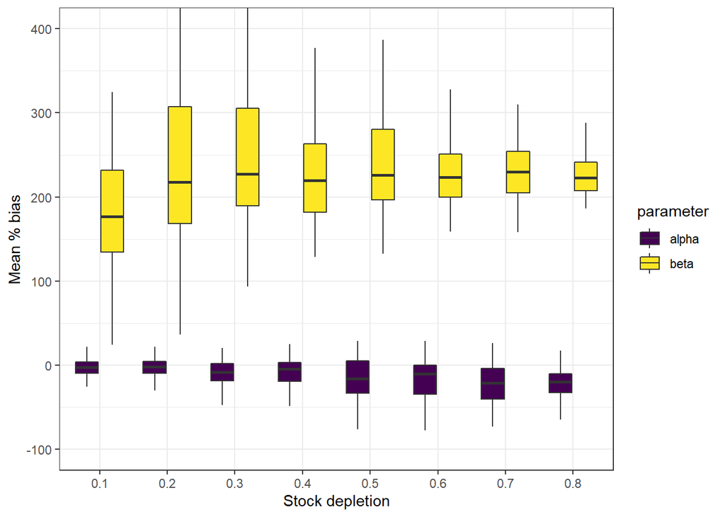

```r
ggplot(data=pms,aes(x=factor(scen), y=mpb, fill=parameter))+
  geom_boxplot(outlier.shape = NA)+
  xlab("Stock depletion") +
  ylab("Mean % bias") +
  coord_cartesian(ylim=c(-100,400))+
  scale_fill_viridis_d(labels=c("alpha", "beta"))+
  theme_bw()
```

Now lets fit 4 different DLMS and figure out the type 1 and 2 errors based on AICc. First run sims:

```r
# source a ugly quick and dirty set of sims
source("ugly-toy-sims-confusion-scenarios.R")

head(srSimsdfConf)
```

```
##         scen MC byr      spwn      rec alpha_true beta_true
## 1 stationary  1   1  75.00000 147.0077        1.5      0.01
## 2 stationary  1   2  73.50385 163.4838        1.5      0.01
## 3 stationary  1   3  81.74191 174.3956        1.5      0.01
## 4 stationary  1   4  87.19779 221.7010        1.5      0.01
## 5 stationary  1   5 110.85048 213.2321        1.5      0.01
## 6 stationary  1   6 106.61606 193.7198        1.5      0.01
```

Next fit four different DLMs to the simulated data so that we can estimate error rates, in this case for a stock depletion of 50% (i.e., fixed 50% harvest rate):

```r
DLMOut<-srSimsdfConf

confusion<-matrix(0,400,6)
confusion<-as.data.frame(confusion)
confusion[,1]<-rep(unique(DLMOut$scen),each=100)
confusion[,2]<-rep(1:100,times=4)
colnames(confusion)<-c("scenario","MC","stationary","alpha","beta","alphabeta")
colnames(confusion)<-c("scenario","MC","stationary","alpha","beta","alphabeta")
confusionAIC <- confusion
confusionBIC <- confusion

for(j in unique(DLMOut$scen)){
  for(i in 1:nMC){
    dlm_model_stat <- fitDLM(data = subset(DLMOut, scen==j & MC==i),
                        alpha_vary = FALSE,
                        beta_vary = FALSE)

    dlm_model_alpha <- fitDLM(data = subset(DLMOut, scen==j & MC==i),
                        alpha_vary = TRUE,
                        beta_vary = FALSE)

    dlm_model_beta <- fitDLM(data = subset(DLMOut, scen==j & MC==i),
                        alpha_vary = FALSE,
                        beta_vary = TRUE)

    dlm_model_both <- fitDLM(data = subset(DLMOut, scen==j & MC==i),
                        alpha_vary = TRUE,
                        beta_vary = TRUE)
    best_mod_AICc <- which.min(c(dlm_model_stat$AICc,dlm_model_alpha$AICc,dlm_model_beta$AICc,dlm_model_both$AICc))
    best_mod_BIC <- which.min(c(dlm_model_stat$BIC,dlm_model_alpha$BIC,dlm_model_beta$BIC,dlm_model_both$BIC))

    confusionAIC[which(confusionAIC$scen==j & confusionAIC$MC==i),2+best_mod_AICc]<-1
    confusionBIC[which(confusionBIC$scen==j & confusionBIC$MC==i),2+best_mod_BIC]<-1

      }
}
```

Then calculate proportion of trials that correctly and incorrectly true underlying dynamics, in this case based on model with lowest AICc:

```r
confusionAIC$InfC <- rep("AIC",dim(confusionAIC)[1])
confusionBIC$InfC <- rep("BIC",dim(confusionBIC)[1])
confusion <- rbind(confusionAIC, confusionBIC)
confusion$InfC <- as.factor(confusion$InfC)

confusionLong <- confusion %>%
  group_by(InfC,scenario) %>%
  dplyr::summarize(
    pStation=sum(stationary)/100,
    pAlpha=sum(alpha)/100,
    pBeta=sum(beta)/100,
    pAlphaBeta=sum(alphabeta)/100) %>%
  pivot_longer(pStation:pAlphaBeta,names_to="estimated",values_to="pMC") %>%
  mutate(trueNum=case_when(scenario=="stationary"~1,
                           scenario=="downAlpha"~2,
                           scenario=="downBeta"~3,
                           scenario=="downAlphaBeta"~4)) %>%
  mutate(estNum=case_when(estimated=="pStation"~1,
                           estimated=="pAlpha"~2,
                           estimated=="pBeta"~3,
                           estimated=="pAlphaBeta"~4))
```

And lastly plot confusion matrix:

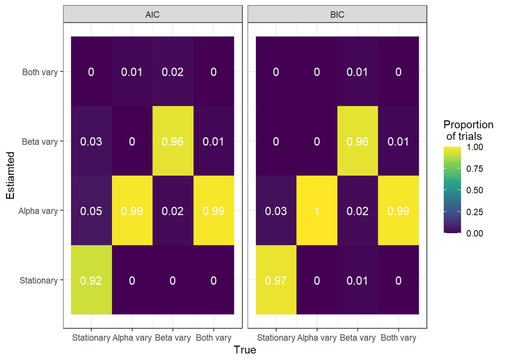

```r
ggplot(data=confusionLong,aes(x=trueNum, y=estNum, fill=pMC))+
   geom_tile(aes(fill = pMC))+
  scale_fill_viridis_c(limits=c(0,1), name="Proportion\n of trials")+
  facet_wrap(~InfC)+
  xlab("True") +
  ylab("Estiamted") +
  geom_text(aes(label = round(pMC, 2)), size = 4, color="white")+
  scale_x_continuous(labels=c("Stationary", "Alpha vary", "Beta vary", "Both vary"), breaks=c(1,2,3,4))+
  scale_y_continuous(labels=c("Stationary", "Alpha vary", "Beta vary", "Both vary"), breaks=c(1,2,3,4))+
  theme_bw()
```